# Introduction

As customer segmentation is an increasingly popular technique used by companies of all sizes to gain a better understanding of their customers and to tailor their products, services, and marketing efforts to meet the specific needs and preferences of different customer segments. This opportunity involves dividing a company's customer base into distinct groups based on common characteristics such as demographics, psychographics, and behavioral patterns.

In this project, I will implement the K-Means Clustering algorithm, which is one of the partition-based clustering algorithms commonly used today, to segment our existing customers into unique clusters based on their demographic and behavioral characterictics and will determine the different customer profiles that the firm have to what kind of responses these groups have provided to recent campaigns.

Importing Libraries

```python
import pandas as pd
import numpy as np
import datetime

import seaborn as sns
import matplotlib.pyplot as plt
from matplotlib.colors import ListedColormap
from mpl_toolkits.mplot3d import Axes3D

from sklearn.preprocessing import LabelEncoder
from sklearn.preprocessing import StandardScaler
from scipy.stats import norm
from sklearn.model_selection import GridSearchCV

from sklearn.decomposition import PCA
from yellowbrick.cluster import KElbowVisualizer
from sklearn.cluster import KMeans, AgglomerativeClustering
from sklearn.metrics import silhouette_score, make_scorer
from yellowbrick.cluster import SilhouetteVisualizer

import warnings
warnings.filterwarnings("ignore")
```

Loading the data

```python
df= pd.read_csv('raw_data.csv')
df.head(20)
```

|  | ID | Year_Birth | Education | Marital_Status | Income | Kidhome | Teenhome | Dt_Customer | Recency | MntWines | ... | AcceptedCmp3 | AcceptedCmp4 | AcceptedCmp5 | AcceptedCmp1 | AcceptedCmp2 | Complain | Z_CostContact | Z_Revenue | Response | Customer_For |
| --- | --- | --- | --- | --- | --- | --- | --- | --- | --- | --- | --- | --- | --- | --- | --- | --- | --- | --- | --- | --- | --- |
| 0 | 5524 | 1957 | Graduation | Single | 58138.0 | 0 | 0 | 2012-04-09 | 58 | 635 | ... | 0 | 0 | 0 | 0 | 0 | 0 | 3 | 11 | 1 | 83894400000000000 |
| 1 | 2174 | 1954 | Graduation | Single | 46344.0 | 1 | 1 | 2014-08-03 | 38 | 11 | ... | 0 | 0 | 0 | 0 | 0 | 0 | 3 | 11 | 0 | 10800000000000000 |
| 2 | 4141 | 1965 | Graduation | Together | 71613.0 | 0 | 0 | 2013-08-21 | 26 | 426 | ... | 0 | 0 | 0 | 0 | 0 | 0 | 3 | 11 | 0 | 40780800000000000 |
| 3 | 6182 | 1984 | Graduation | Together | 26646.0 | 1 | 0 | 2014-10-02 | 26 | 11 | ... | 0 | 0 | 0 | 0 | 0 | 0 | 3 | 11 | 0 | 5616000000000000 |
| 4 | 5324 | 1981 | PhD | Married | 58293.0 | 1 | 0 | 2014-01-19 | 94 | 173 | ... | 0 | 0 | 0 | 0 | 0 | 0 | 3 | 11 | 0 | 27734400000000000 |
| 5 | 7446 | 1967 | Master | Together | 62513.0 | 0 | 1 | 2013-09-09 | 16 | 520 | ... | 0 | 0 | 0 | 0 | 0 | 0 | 3 | 11 | 0 | 39139200000000000 |
| 6 | 965 | 1971 | Graduation | Divorced | 55635.0 | 0 | 1 | 2012-11-13 | 34 | 235 | ... | 0 | 0 | 0 | 0 | 0 | 0 | 3 | 11 | 0 | 65059200000000000 |
| 7 | 6177 | 1985 | PhD | Married | 33454.0 | 1 | 0 | 2013-08-05 | 32 | 76 | ... | 0 | 0 | 0 | 0 | 0 | 0 | 3 | 11 | 0 | 42163200000000000 |
| 8 | 4855 | 1974 | PhD | Together | 30351.0 | 1 | 0 | 2013-06-06 | 19 | 14 | ... | 0 | 0 | 0 | 0 | 0 | 0 | 3 | 11 | 1 | 47347200000000000 |
| 9 | 5899 | 1950 | PhD | Together | 5648.0 | 1 | 1 | 2014-03-13 | 68 | 28 | ... | 1 | 0 | 0 | 0 | 0 | 0 | 3 | 11 | 0 | 23155200000000000 |
| 10 | 387 | 1976 | Basic | Married | 7500.0 | 0 | 0 | 2012-11-13 | 59 | 6 | ... | 0 | 0 | 0 | 0 | 0 | 0 | 3 | 11 | 0 | 65059200000000000 |
| 11 | 2125 | 1959 | Graduation | Divorced | 63033.0 | 0 | 0 | 2013-11-15 | 82 | 194 | ... | 0 | 0 | 0 | 0 | 0 | 0 | 3 | 11 | 0 | 33350400000000000 |
| 12 | 8180 | 1952 | Master | Divorced | 59354.0 | 1 | 1 | 2013-11-15 | 53 | 233 | ... | 0 | 0 | 0 | 0 | 0 | 0 | 3 | 11 | 0 | 33350400000000000 |
| 13 | 2569 | 1987 | Graduation | Married | 17323.0 | 0 | 0 | 2012-10-10 | 38 | 3 | ... | 0 | 0 | 0 | 0 | 0 | 0 | 3 | 11 | 0 | 67996800000000000 |
| 14 | 2114 | 1946 | PhD | Single | 82800.0 | 0 | 0 | 2012-11-24 | 23 | 1006 | ... | 0 | 0 | 1 | 1 | 0 | 0 | 3 | 11 | 1 | 64108800000000000 |
| 15 | 9736 | 1980 | Graduation | Married | 41850.0 | 1 | 1 | 2012-12-24 | 51 | 53 | ... | 0 | 0 | 0 | 0 | 0 | 0 | 3 | 11 | 0 | 61516800000000000 |
| 16 | 4939 | 1946 | Graduation | Together | 37760.0 | 0 | 0 | 2012-08-31 | 20 | 84 | ... | 0 | 0 | 0 | 0 | 0 | 0 | 3 | 11 | 0 | 71452800000000000 |
| 17 | 6565 | 1949 | Master | Married | 76995.0 | 0 | 1 | 2013-03-28 | 91 | 1012 | ... | 0 | 0 | 0 | 1 | 0 | 0 | 3 | 11 | 0 | 53395200000000000 |
| 18 | 2278 | 1985 | 2n Cycle | Single | 33812.0 | 1 | 0 | 2012-03-11 | 86 | 4 | ... | 0 | 0 | 0 | 0 | 0 | 0 | 3 | 11 | 0 | 86400000000000000 |
| 19 | 9360 | 1982 | Graduation | Married | 37040.0 | 0 | 0 | 2012-08-08 | 41 | 86 | ... | 0 | 0 | 0 | 0 | 0 | 0 | 3 | 11 | 0 | 73440000000000000 |

20 rows × 30 columns

This dataset includes 4 main stream:

- Demographic infromations about Customers includes such as id, birth year of the customer, their income level, the number of kids or teenagers in the household etc.
- Behavioral informations that indicates customer buying habit regarding on different product categories including MntWines, MntFruits, MntMeatProducts, MntFishProducts etc.
- Place information that indicates where customer bought the related products including:
  - number of purchases on website(NumWebPurchases)
  - number of purchases from the stores catalog (NumCatalogPurchases)
- Informations about the recent campaings including:
  - amount of spending with promotions (NumDealsPurchases)
  - whether the customer accepted the campaings or not (AcceptCmp1, AcceptCmp2, AcceptCmp3 etc.)

```python
df.info()
```

```
<class 'pandas.core.frame.DataFrame'>
RangeIndex: 2216 entries, 0 to 2215
Data columns (total 30 columns):
 #   Column               Non-Null Count  Dtype
---  ------               --------------  -----
 0   ID                   2216 non-null   int64
 1   Year_Birth           2216 non-null   int64
 2   Education            2216 non-null   object
 3   Marital_Status       2216 non-null   object
 4   Income               2216 non-null   float64
 5   Kidhome              2216 non-null   int64
 6   Teenhome             2216 non-null   int64
 7   Dt_Customer          2216 non-null   object
 8   Recency              2216 non-null   int64
 9   MntWines             2216 non-null   int64
```

[output cut: 22 more lines]

```python
df.describe()
```

|  | ID | Year_Birth | Income | Kidhome | Teenhome | Recency | MntWines | MntFruits | MntMeatProducts | MntFishProducts | ... | AcceptedCmp3 | AcceptedCmp4 | AcceptedCmp5 | AcceptedCmp1 | AcceptedCmp2 | Complain | Z_CostContact | Z_Revenue | Response | Customer_For |
| --- | --- | --- | --- | --- | --- | --- | --- | --- | --- | --- | --- | --- | --- | --- | --- | --- | --- | --- | --- | --- | --- |
| count | 2216.000000 | 2216.000000 | 2216.000000 | 2216.000000 | 2216.000000 | 2216.000000 | 2216.000000 | 2216.000000 | 2216.000000 | 2216.000000 | ... | 2216.000000 | 2216.000000 | 2216.000000 | 2216.000000 | 2216.000000 | 2216.000000 | 2216.0 | 2216.0 | 2216.000000 | 2.216000e+03 |
| mean | 5588.353339 | 1968.820397 | 52247.251354 | 0.441787 | 0.505415 | 49.012635 | 305.091606 | 26.356047 | 166.995939 | 37.637635 | ... | 0.073556 | 0.074007 | 0.073105 | 0.064079 | 0.013538 | 0.009477 | 3.0 | 11.0 | 0.150271 | 4.423735e+16 |
| std | 3249.376275 | 11.985554 | 25173.076661 | 0.536896 | 0.544181 | 28.948352 | 337.327920 | 39.793917 | 224.283273 | 54.752082 | ... | 0.261106 | 0.261842 | 0.260367 | 0.244950 | 0.115588 | 0.096907 | 0.0 | 0.0 | 0.357417 | 2.008532e+16 |
| min | 0.000000 | 1893.000000 | 1730.000000 | 0.000000 | 0.000000 | 0.000000 | 0.000000 | 0.000000 | 0.000000 | 0.000000 | ... | 0.000000 | 0.000000 | 0.000000 | 0.000000 | 0.000000 | 0.000000 | 3.0 | 11.0 | 0.000000 | 0.000000e+00 |
| 25% | 2814.750000 | 1959.000000 | 35303.000000 | 0.000000 | 0.000000 | 24.000000 | 24.000000 | 2.000000 | 16.000000 | 3.000000 | ... | 0.000000 | 0.000000 | 0.000000 | 0.000000 | 0.000000 | 0.000000 | 3.0 | 11.0 | 0.000000 | 2.937600e+16 |
| 50% | 5458.500000 | 1970.000000 | 51381.500000 | 0.000000 | 0.000000 | 49.000000 | 174.500000 | 8.000000 | 68.000000 | 12.000000 | ... | 0.000000 | 0.000000 | 0.000000 | 0.000000 | 0.000000 | 0.000000 | 3.0 | 11.0 | 0.000000 | 4.432320e+16 |
| 75% | 8421.750000 | 1977.000000 | 68522.000000 | 1.000000 | 1.000000 | 74.000000 | 505.000000 | 33.000000 | 232.250000 | 50.000000 | ... | 0.000000 | 0.000000 | 0.000000 | 0.000000 | 0.000000 | 0.000000 | 3.0 | 11.0 | 0.000000 | 5.927040e+16 |
| max | 11191.000000 | 1996.000000 | 666666.000000 | 2.000000 | 2.000000 | 99.000000 | 1493.000000 | 199.000000 | 1725.000000 | 259.000000 | ... | 1.000000 | 1.000000 | 1.000000 | 1.000000 | 1.000000 | 1.000000 | 3.0 | 11.0 | 1.000000 | 9.184320e+16 |

8 rows × 27 columns

After also checking the existence of the strings that indicates the Null data points such as like "NaN", "nan" etc.  
Clearly known that the dataset has no missing data.

```python
df.isnull().sum()
```

```
ID                     0
Year_Birth             0
Education              0
Marital_Status         0
Income                 0
Kidhome                0
Teenhome               0
Dt_Customer            0
Recency                0
MntWines               0
MntFruits              0
MntMeatProducts        0
MntFishProducts        0
MntSweetProducts       0
MntGoldProds           0
NumDealsPurchases      0
NumWebPurchases        0
NumCatalogPurchases    0
NumStorePurchases      0
NumWebVisitsMonth      0
AcceptedCmp3           0
AcceptedCmp4           0
AcceptedCmp5           0
AcceptedCmp1           0
AcceptedCmp2           0
Complain               0
Z_CostContact          0
Z_Revenue              0
Response               0
Customer_For           0
dtype: int64
```

Checking duplicates

```python
duplicates = df.duplicated()
print("Number of duplicates:", duplicates.sum())
```

```
Number of duplicates: 0
```

# Feature Engineering

1. Year_Birth column just shows the year of birth. This situation can make the analysis hard to comprehend. Therefore, I decided to convert the column into Age column that shows the corresponding age of the customer.

```python
#Creating Age column
current_year = datetime.datetime.now().year
df['Age'] = current_year - df['Year_Birth']
```

2. By summing up the procuts columns to get a total spending value for each customer. It might be a good indicator for the rest of the analysis

```python
#Creating total amount of spending for the products
cols = ["MntWines","MntFruits","MntMeatProducts","MntFishProducts","MntSweetProducts","MntGoldProds"]
df['TotalSpent'] = df[cols].sum(axis=1)
```

3. Martial_Status columns unneccasirly classified when thinking about the purpose of the pipeline. Therefore, I simplified the various types of martial statues into two categories : "Partner" and "Alone".

```python
#Simplify Martiul Status
conditions = ["Married", "Together"]
values = "Partner"
df["Living_With"] = df["Marital_Status"].map(lambda x: values if x in conditions else "Alone")
```

4. Again I simplified the number of children that the household had. Because the details is not needed in this project.

```python
#Total number of kids in the household
df["Children"] = df[["Kidhome", "Teenhome"]].sum(axis=1)
```

5. I created this column to understand whether the customer is parent or not.

```python
#Are the customers parent or not
df["Parenthood"] = (df["Children"] > 0).astype(int)
```

6. Again, there is so much redundancy in the education column, simplified to basic educational levels.

There is newly 3 categories : Undergraduate, Graduate and Postgraduate

```python
#Segmenting column into three columns
education_map = {"Basic": "Undergraduate",
                 "2n Cycle": "Undergraduate",
                 "Graduation": "Graduate",
                 "Master": "Postgraduate",
                 "PhD": "Postgraduate"}
df["Education"] = df["Education"].map(education_map)
```

renaming some columns and removing unwanted columns

```python
#Renaming the confusing names and dropping the excessive features
df=df.rename(columns={"MntWines": "Wines","MntFruits":"Fruits","MntMeatProducts":"Meat","MntFishProducts":"Fish","MntSweetProducts":"Sweets","MntGoldProds":"Gold"})
to_drop = ["Marital_Status", "Dt_Customer", "Z_CostContact", "Z_Revenue", "Year_Birth", "ID"]
df = df.drop(to_drop, axis=1)
```

After Feature Engineering process, 185 values founded as duplicates.

```python
duplicates = df.duplicated()
print("Number of duplicates:", duplicates.sum())
```

```
Number of duplicates: 185
```

```python
df.drop_duplicates(inplace=True)
duplicates = df.duplicated()
print("Number of duplicates after removal:", duplicates.sum())
```

```
Number of duplicates after removal: 0
```

```python
df.head()
```

|  | Education | Income | Kidhome | Teenhome | Recency | Wines | Fruits | Meat | Fish | Sweets | ... | AcceptedCmp1 | AcceptedCmp2 | Complain | Response | Customer_For | Age | TotalSpent | Living_With | Children | Parenthood |
| --- | --- | --- | --- | --- | --- | --- | --- | --- | --- | --- | --- | --- | --- | --- | --- | --- | --- | --- | --- | --- | --- |
| 0 | Graduate | 58138.0 | 0 | 0 | 58 | 635 | 88 | 546 | 172 | 88 | ... | 0 | 0 | 0 | 1 | 83894400000000000 | 66 | 1617 | Alone | 0 | 0 |
| 1 | Graduate | 46344.0 | 1 | 1 | 38 | 11 | 1 | 6 | 2 | 1 | ... | 0 | 0 | 0 | 0 | 10800000000000000 | 69 | 27 | Alone | 2 | 1 |
| 2 | Graduate | 71613.0 | 0 | 0 | 26 | 426 | 49 | 127 | 111 | 21 | ... | 0 | 0 | 0 | 0 | 40780800000000000 | 58 | 776 | Partner | 0 | 0 |
| 3 | Graduate | 26646.0 | 1 | 0 | 26 | 11 | 4 | 20 | 10 | 3 | ... | 0 | 0 | 0 | 0 | 5616000000000000 | 39 | 53 | Partner | 1 | 1 |
| 4 | Postgraduate | 58293.0 | 1 | 0 | 94 | 173 | 43 | 118 | 46 | 27 | ... | 0 | 0 | 0 | 0 | 27734400000000000 | 42 | 422 | Partner | 1 | 1 |

5 rows × 29 columns

# Data Preprocessing

- Removing outliers
- Encoding classification columns
- droppping some features with the support of correlation matrix
- Standardizing data for Principal Component Analysis
- Implementing Dimensionality Reduction with PCA

#### 1. Removing outliers

- Firstly I decided to remove the outliers, because Kmeans Clustering techniques are very sensitive to outliers.
- Therefore, it is important to visualize columns and check their datapoints in scatter plot to see if there is any anomaly in dataset.
- After examining each features in scatterplot by comparing with other features.

It founded that the "Age" column and "Income" column has outliers that can effect the clustering algoritm.

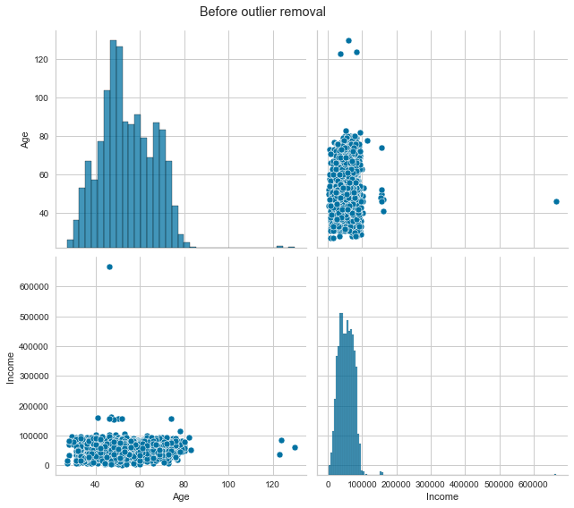

```
The total number of data-points after removing the outliers are: 2020
```

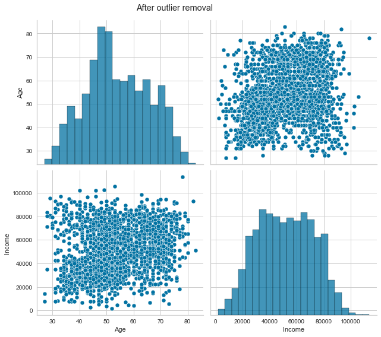

```python
g1 = sns.pairplot(df[['Age','Income']])
g1.fig.set_size_inches(10, 8)
g1.fig.suptitle('Before outlier removal', y=1.02)
plt.show()

# Rules for outliers
df = df[(df["Age"]<100)]
df = df[(df["Income"]<120000)]
print("The total number of data-points after removing the outliers are:", len(df))

g2 = sns.pairplot(df[['Age','Income']])
g2.fig.set_size_inches(10, 8)
g2.fig.suptitle('After outlier removal', y=1.02)
plt.show()
```

#### 2. Encoding

- Encoding the dataset is necessary because Kmeans Clustering is only assumes the numerical values.
- Therefore, I need to convert the categorical features to numerical vales.
- While doing that I realized that the LabelEncoder() assigns a unique integer label to each category in the feature,  
  starting with 0 for the first category and increasing by 1 for each subsequent category.  
  It means this encoding does not take into account the relative importance of classification values.
- As its observed, I decided to create custom mapping for values in case of considering importance of classification values.

```python
LE = LabelEncoder()
LE.fit(df['Education'])
mapping = dict(zip(LE.classes_, LE.transform(LE.classes_)))
mapping
```

```
{'Graduate': 0, 'Postgraduate': 1, 'Undergraduate': 2}
```

```python
edu_mapping = {'Graduate': 1, 'Postgraduate': 2, 'Undergraduate': 0}
liv_mapping = {'Alone': 0, 'Partner': 1}
df['Education'] = df['Education'].replace(edu_mapping)
df['Living_With'] = df['Living_With'].replace(liv_mapping)
```

#### 3. Correlation matrix

- I decided to implement a correlation matrix in this stage to check the correlations between features.
- My main purpose was before implementing PCA, I wanted to reduce the high dimensionality of the dataset

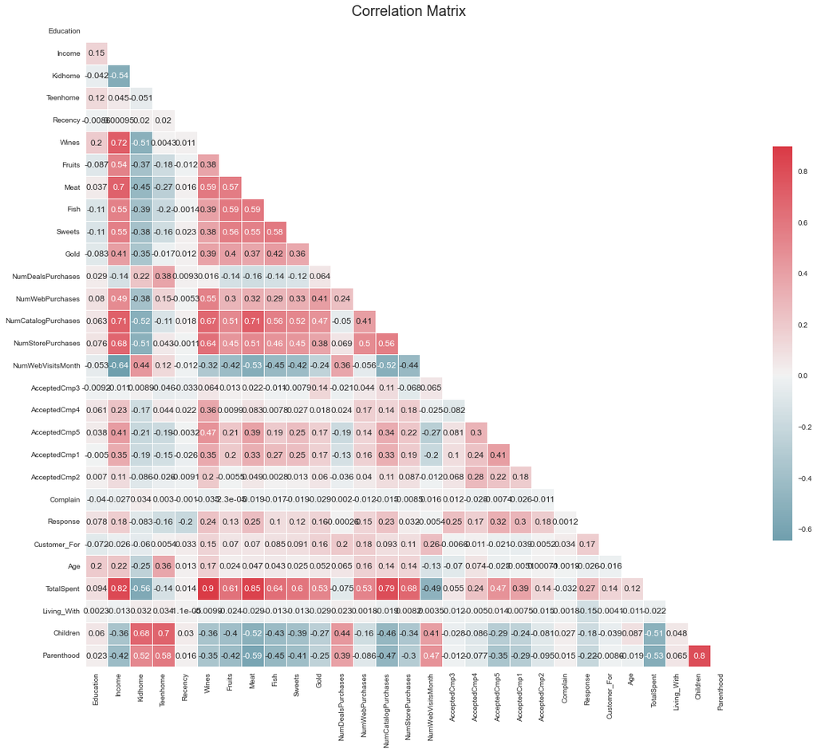

```python
corrmat = df.corr()

fig, ax = plt.subplots(figsize=(20, 20))
mask = np.zeros_like(corrmat, dtype=np.bool)
mask[np.triu_indices_from(mask)] = True
cmap = sns.diverging_palette(220, 10, as_cmap=True)
sns.heatmap(corrmat, mask=mask, cmap=cmap, center=0, annot=True, square=True, linewidths=.5, cbar_kws={"shrink": .5}, ax=ax)

plt.title('Correlation Matrix', fontsize= 20)
```

```python
#Checking the high collenarity
corrmat = df.corr()
high_corr = corrmat[abs(corrmat) > 0.7]
high_corr = high_corr.unstack().sort_values(ascending=False).drop_duplicates()
high_corr = high_corr[high_corr != 1.0]

for i in range(0, len(high_corr)):
    print(high_corr.index[i][0], 'and',high_corr.index[i][1], 'columns have correlation around:', round(high_corr[i], 2))
```

```
Wines and TotalSpent columns have correlation around: 0.9
Meat and TotalSpent columns have correlation around: 0.85
Income and TotalSpent columns have correlation around: 0.82
Children and Parenthood columns have correlation around: 0.8
TotalSpent and NumCatalogPurchases columns have correlation around: 0.79
Wines and Income columns have correlation around: 0.72
NumCatalogPurchases and Meat columns have correlation around: 0.71
NumCatalogPurchases and Income columns have correlation around: 0.71
Education and Income columns have correlation around: nan
```

```python
#dropping colunms
df_copy = df.copy()

drop_cols = [
    'Recency',
    'AcceptedCmp1',
    'AcceptedCmp2',
    'AcceptedCmp3',
    'AcceptedCmp4',
    'AcceptedCmp5',
    'Complain',
    'Response'
]
df_copy = df_copy.drop(drop_cols, axis=1)
df_copy.columns
```

```
Index(['Education', 'Income', 'Kidhome', 'Teenhome', 'Wines', 'Fruits', 'Meat',
       'Fish', 'Sweets', 'Gold', 'NumDealsPurchases', 'NumWebPurchases',
       'NumCatalogPurchases', 'NumStorePurchases', 'NumWebVisitsMonth',
       'Customer_For', 'Age', 'TotalSpent', 'Living_With', 'Children',
       'Parenthood'],
      dtype='object')
```

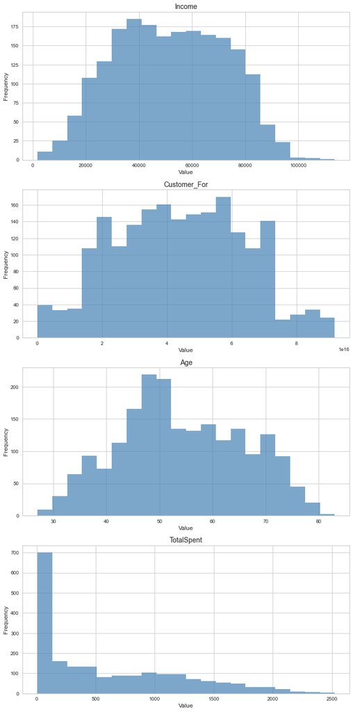

```python
dist_cols = ['Income','Customer_For', 'Age', 'TotalSpent']

fig, axs = plt.subplots(nrows=len(dist_cols), figsize=(10, 20))


for i, column in enumerate(dist_cols):
    axs[i].hist(df_copy[column], bins=20, color='steelblue', alpha=0.7)
    axs[i].set_title(column, fontsize=14)
    axs[i].set_xlabel('Value', fontsize=12)
    axs[i].set_ylabel('Frequency', fontsize=12)
    axs[i].grid(True)


plt.tight_layout()
plt.show()
```

#### 4. Standardization

- StandardScaler is subtract the mean of each feature from each observation and divides those values  
  the std of the feature. It provides where the means of the features close around the 0 and 1 standard deviation.
- The purpose of making this, PCA is sensitive the different ranges between the features. helps to equalize the scale of different numerical features in a dataset.
- The other main purpose is that ,it helps to normalize the distribution of features that are not normally distributed.

```python
scaler = StandardScaler()
scaler.fit(df_copy)
scaled_df = pd.DataFrame(scaler.transform(df_copy),columns= df_copy.columns )
```

```python
scaled_df.describe()
```

|  | Education | Income | Kidhome | Teenhome | Wines | Fruits | Meat | Fish | Sweets | Gold | ... | NumWebPurchases | NumCatalogPurchases | NumStorePurchases | NumWebVisitsMonth | Customer_For | Age | TotalSpent | Living_With | Children | Parenthood |
| --- | --- | --- | --- | --- | --- | --- | --- | --- | --- | --- | --- | --- | --- | --- | --- | --- | --- | --- | --- | --- | --- |
| count | 2.020000e+03 | 2.020000e+03 | 2.020000e+03 | 2.020000e+03 | 2.020000e+03 | 2.020000e+03 | 2.020000e+03 | 2.020000e+03 | 2.020000e+03 | 2.020000e+03 | ... | 2.020000e+03 | 2.020000e+03 | 2.020000e+03 | 2.020000e+03 | 2.020000e+03 | 2.020000e+03 | 2.020000e+03 | 2.020000e+03 | 2.020000e+03 | 2.020000e+03 |
| mean | -4.572800e-17 | -1.143200e-16 | -7.474769e-17 | 3.165784e-17 | -5.803938e-17 | 1.407015e-17 | -7.035077e-18 | 3.957231e-17 | 1.275108e-17 | 3.869292e-17 | ... | -6.331569e-17 | -5.628061e-17 | -1.407015e-17 | -1.108025e-16 | 1.424603e-16 | -1.459778e-16 | 7.826523e-17 | -7.562707e-17 | 5.803938e-17 | 5.276307e-17 |
| std | 1.000248e+00 | 1.000248e+00 | 1.000248e+00 | 1.000248e+00 | 1.000248e+00 | 1.000248e+00 | 1.000248e+00 | 1.000248e+00 | 1.000248e+00 | 1.000248e+00 | ... | 1.000248e+00 | 1.000248e+00 | 1.000248e+00 | 1.000248e+00 | 1.000248e+00 | 1.000248e+00 | 1.000248e+00 | 1.000248e+00 | 1.000248e+00 | 1.000248e+00 |
| min | -1.942931e+00 | -2.412601e+00 | -8.265399e-01 | -9.324926e-01 | -9.084412e-01 | -6.632203e-01 | -7.557195e-01 | -6.854123e-01 | -6.562450e-01 | -8.501841e-01 | ... | -1.495553e+00 | -9.452131e-01 | -1.798955e+00 | -2.201120e+00 | -2.199708e+00 | -2.324395e+00 | -1.001195e+00 | -1.335054e+00 | -1.277188e+00 | -1.600815e+00 |
| 25% | -4.104356e-01 | -7.863860e-01 | -8.265399e-01 | -9.324926e-01 | -8.373388e-01 | -6.129339e-01 | -6.829396e-01 | -6.307547e-01 | -6.321902e-01 | -6.760203e-01 | ... | -7.689978e-01 | -9.452131e-01 | -8.699675e-01 | -9.646735e-01 | -7.470564e-01 | -6.959054e-01 | -8.949301e-01 | -1.335054e+00 | -1.277188e+00 | -1.600815e+00 |
| 50% | -4.104356e-01 | -1.205183e-02 | -8.265399e-01 | -9.324926e-01 | -3.796174e-01 | -4.620747e-01 | -4.464050e-01 | -4.667817e-01 | -4.638062e-01 | -3.663956e-01 | ... | -4.244235e-02 | -2.306433e-01 | -2.506426e-01 | 2.717735e-01 | 2.363402e-04 | -9.593574e-02 | -3.494917e-01 | 7.490334e-01 | 6.372665e-02 | 6.246816e-01 |
| 75% | 1.122060e+00 | 8.006091e-01 | 1.038947e+00 | 8.980565e-01 | 5.943368e-01 | 1.665052e-01 | 2.904912e-01 | 2.255485e-01 | 1.616200e-01 | 2.335022e-01 | ... | 6.841131e-01 | 4.839265e-01 | 6.783447e-01 | 6.839225e-01 | 7.464539e-01 | 8.468737e-01 | 7.305925e-01 | 7.490334e-01 | 6.372665e-02 | 6.246816e-01 |
| max | 1.122060e+00 | 2.995594e+00 | 2.904434e+00 | 2.728606e+00 | 3.514718e+00 | 4.340276e+00 | 7.090861e+00 | 4.033365e+00 | 5.646127e+00 | 5.361661e+00 | ... | 8.312945e+00 | 9.058764e+00 | 2.226657e+00 | 6.041859e+00 | 2.372219e+00 | 2.475363e+00 | 3.182990e+00 | 7.490334e-01 | 2.745556e+00 | 6.246816e-01 |

8 rows × 21 columns

All distributions are on the same line, standardisation is successful

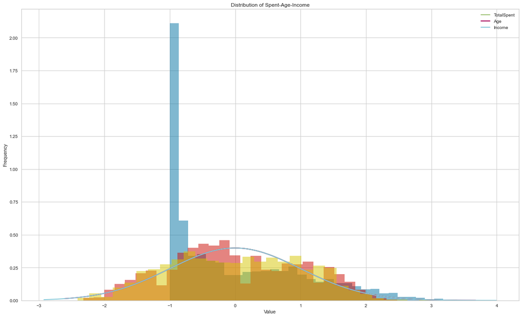

```python
cols = ['TotalSpent','Age','Income']

plt.figure(figsize=(20,12))
for col in cols:
    x = scaled_df[col]
    plt.hist(x, bins=30, alpha=0.5, density=True)

    mu, std = np.mean(x), np.std(x)

    # Add a normal distribution line to the plot
    xmin, xmax = plt.xlim()
    x = np.linspace(xmin, xmax, 100)
    p = norm.pdf(x, mu, std)
    plt.plot(x, p, linewidth=2, label=col)

plt.xlabel('Value')
plt.ylabel('Frequency')
plt.title('Distribution of Spent-Age-Income')
plt.legend()
plt.show()
```

before getting PCA, I wanted to loop general Kmeans model to see the silhouette score to make sure that  
everything runs like expected

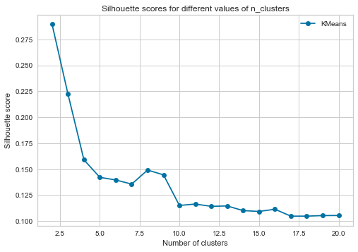

```python
n_clusters_range = range(2, 21)

silhouette_scores_kmeans = []
silhouette_scores_agg = []

for n_clusters in n_clusters_range:

    #KMeans Clustering
    kmeans = KMeans(n_clusters=n_clusters, init='k-means++', n_init=1, random_state=42).fit(scaled_df)
    labels_kmeans = kmeans.labels_
    score_kmeans = silhouette_score(scaled_df, labels_kmeans)
    silhouette_scores_kmeans.append(score_kmeans)


plt.plot(n_clusters_range, silhouette_scores_kmeans, marker='o', label='KMeans')
plt.xlabel('Number of clusters')
plt.ylabel('Silhouette score')
plt.title('Silhouette scores for different values of n_clusters')
plt.legend()
plt.show()
```

Silhouettte scores are low which is something acceptable. Important part here is that after PCA  
I will use this silhouette scores as a metric compare both silhouette scores to see PCA was the right decision or not.

### SCREE PLOT

- Scree plot is a tool to procedure how many n_compnents for PCA.
- It works the same prensib like Elbow method.
- According to graphical inference, it is obvious to n_components = 3 is where the variance ratios are not decreasing.
- After deciding PCA parameter as 3, I accepted to create 3-dimesional dataset.

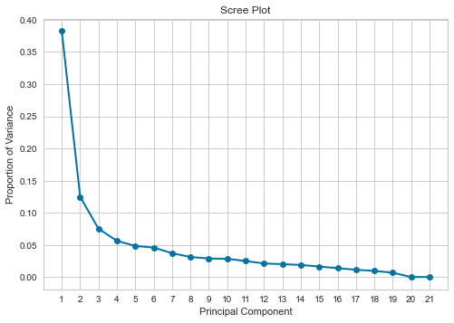

```python
pca = PCA().fit(scaled_df)
variance_ratios = pca.explained_variance_ratio_
plt.plot(range(1, len(variance_ratios)+1), variance_ratios, 'bo-', linewidth=2)
plt.xticks(np.arange(1, len(variance_ratios)+1, 1.0))
plt.xlabel('Principal Component')
plt.ylabel('Proportion of Variance')
plt.title('Scree Plot')

plt.show()
```

The elbow point strongly suggests that the appropriate number of components for PCA is 3

```python
pca = PCA(n_components=3)
pca.fit(scaled_df)
transformed_df = pd.DataFrame(pca.transform(scaled_df), columns=(["Feature1","Feature2","Feature3"]))
```

- checking the silhouette scores after PCA show us a huge impact on the scores.
- It indicates that our clusters are getting more seperated from each others centroid.

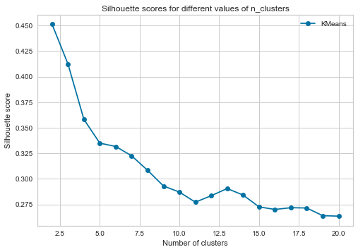

```python
n_clusters_range = range(2, 21)

silhouette_scores_kmeans = []


for n_clusters in n_clusters_range:

    #KMeans Clustering
    kmeans = KMeans(n_clusters=n_clusters, init='k-means++', n_init=1, random_state=42).fit(transformed_df)
    labels_kmeans = kmeans.labels_
    score_kmeans = silhouette_score(transformed_df, labels_kmeans)
    silhouette_scores_kmeans.append(score_kmeans)


plt.plot(n_clusters_range, silhouette_scores_kmeans, marker='o', label='KMeans')
plt.xlabel('Number of clusters')
plt.ylabel('Silhouette score')
plt.title('Silhouette scores for different values of n_clusters')
plt.legend()
plt.show()
```

#### Elbow Method

- The elbow method is a graphical technique for determining the optimal number of clusters within a clustering algorithm.
- It is a widely employed strategy. It is not, however, a conclusive or infallible procedure, and its outcomes should be read with care.
- According to below graph, the curviness of the graph is not that promising.

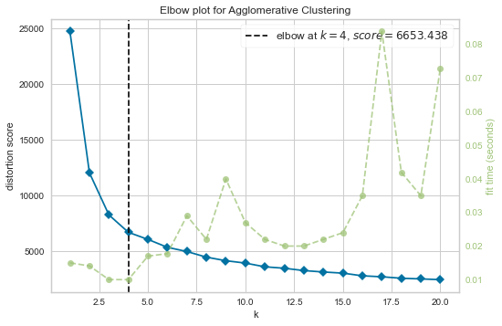

```python
visualizer = KElbowVisualizer(kmeans, k=(1,21), title= "Elbow plot for Agglomerative Clustering")
visualizer.fit(transformed_df)
visualizer.show(figsize=(20,16))
```

As the elbow is not promising I decided to loop through the best possbile k-means clustering method when the clusters are 2,3,4

GridSearchCV

- I decided to implement grid search without providing n_clusters to see the best possible parameter.
- Then I want to reach out best possible outcome for analyzing.

```python
param_grid = {
    'init': ['k-means++', 'random'],
    'n_init': ['auto', 1, 5, 10],
    'max_iter': [i for i in range(1, 20, 5)],
    'algorithm':['lloyd', 'elkan', 'auto', 'full']
}

silhouette_scorer = make_scorer(silhouette_score)

kmeans = KMeans()

grid_search = GridSearchCV(kmeans, param_grid=param_grid, scoring=silhouette_scorer)
grid_search.fit(transformed_df)

print("Best parameters: ", grid_search.best_params_)
```

```
Best parameters:  {'algorithm': 'lloyd', 'init': 'k-means++', 'max_iter': 1, 'n_init': 'auto'}
```

Now, it is time to loop through a kmeans clustering algorithm with the following n_clusters_lists = [2,3,4]

[figure not shown]

[figure not shown]

[figure not shown]

```python
n_clusters_list = [2, 3, 4]

# Loop over the n_clusters values
for n_clusters in n_clusters_list:

    kmeans = KMeans(n_clusters=n_clusters, init='k-means++', n_init='auto', algorithm='lloyd', random_state=42).fit(transformed_df)

    score_kmeans = silhouette_score(transformed_df, kmeans.labels_)

    df[f'Kmeans_{n_clusters}'] = kmeans.labels_
```

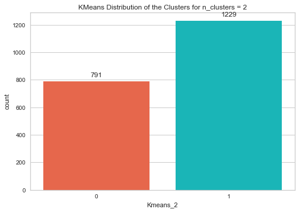

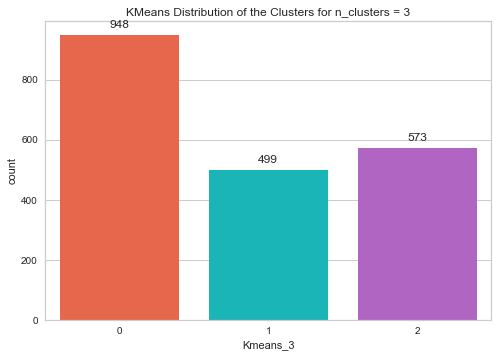

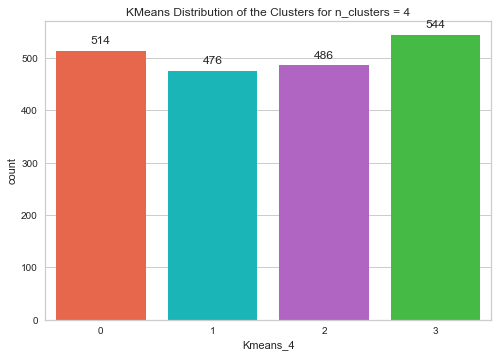

```python
for n_clusters in n_clusters_list:

    pal = ["#FF5733","#00CED1","#BA55D3","#32CD32"]
    pl = sns.countplot(x=f'Kmeans_{n_clusters}', data=df, palette=pal) # Plot the KMeans distribution of the clusters
    pl.set_title(f"KMeans Distribution of the Clusters for n_clusters = {n_clusters}")

    for p in pl.patches:
        pl.annotate(format(p.get_height(), '.0f'),
                    (p.get_x() + p.get_width() / 2., p.get_height()),
                    ha='center', va='center',
                    xytext=(0, 10),
                    textcoords='offset points')

    plt.show()
```

first I want to check the balance of the clusters.

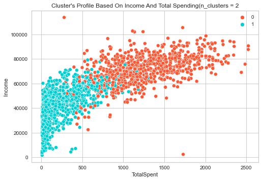

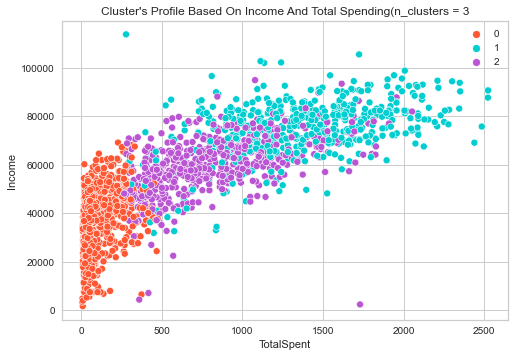

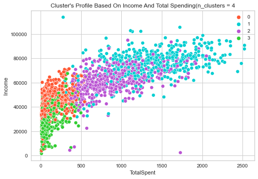

```python
for n_clusters in n_clusters_list:
    pl = sns.scatterplot(data = df,x=df["TotalSpent"], y=df["Income"],hue=df[f"Kmeans_{n_clusters}"], palette= pal)
    pl.set_title(f"Cluster's Profile Based On Income And Total Spending(n_clusters = {n_clusters}")
    plt.legend()
    plt.show()
```

- While (k)=2 and (k) = 3 the shapes of the clusters can be clearly observed
- While(k)=4,
  - the clusters look like the sum of the above scenarios. I'm also in the scenario with the lowest silhouette score right now.

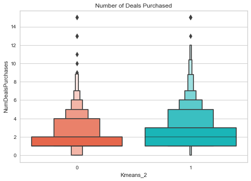

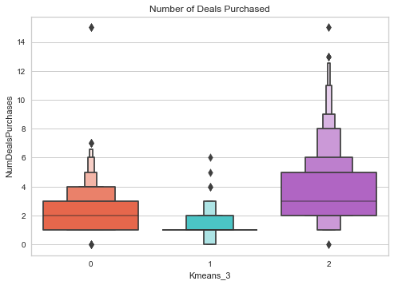

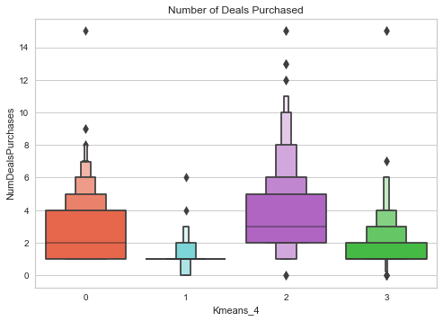

```python
for n_clusters in n_clusters_list:
    pl=sns.boxenplot(y=df["NumDealsPurchases"],x=df[f"Kmeans_{n_clusters}"], palette= pal)
    pl.set_title("Number of Deals Purchased")
    plt.show()
```

- While (k)=2,
  - When the density of shopping made within the campaign program is analyzed, the smallest difference between the scenarios is seen.
- While(k)=3 and While(k)=4 ,
  - There are differences in the amount of sales made within the campaign between the groups. This is an indication that we have two scenarios segmented into customer behavior.